# Bayesian Linear Regression

```python
import numpy as np
from numpy.random import multivariate_normal
from scipy.stats import multivariate_normal as m_norm
from scipy.stats import norm
from numpy.random import normal
from data import load_data
import matplotlib.pyplot as plt
from ipywidgets import interact, interactive, fixed, interact_manual
import ipywidgets as widgets
```

```python
X, y = load_data("weatherHistory.csv", "\n", ",", target_col=4, numeric_target=True, ignore_cols=[0,1,2,3,6,7,8,9,11])
```

Model can be defined as: \begin{align} y & = X^{T}\theta + \varepsilon \\ \varepsilon & \sim \mathcal{N}(0,\sigma^{2}) \\ \theta & \sim \mathcal{N}(m_{0},S_{0}) \end{align}

```python
N,M = X.shape

# Parameters for prior on weight
m0 = np.random.random([M,1])
S0 = np.random.random([M,M])
```

```python
# Noise variance
var = 0.1
```

Posterior distribution over target variable can be predicted by:

\begin{align} p(y_{*}|X,y,x_{*}) & = \int p(y_{*}|x_{*},\theta) p(\theta|X,y) d\theta \\ & = \int \mathcal{N}(y_{*}|X^{T}\theta,\sigma^{2}) \mathcal{N}(\theta|m_{N},S_{N}) d\theta \end{align}

But there is a problem, we do not yet have $m_{N},S_{N}$ In order to compute these, we first transform posterior, which is defined as:

\begin{align} p(\theta|X,y) = p(y|X,\theta)p(\theta) \end{align}

into log space, where we sum them and solve for these parameters using a procedure called "Complete the squares". PS: Normalisation constant in posterior is omitted to keep things simple. The result after performing completing squares would be:

\begin{align} S_{N} & = (\sigma^{-2}X^{T}X + S_{0}^{-1})^{-1} \\ m_{N} & = S_{N}(\sigma^{-2}X^{T}y + S_{0}^{-1}m_{0}) \end{align}

```python
# Posterior parameters

SN = np.linalg.inv(1/var * (X.T @ X) + np.linalg.inv(S0))
mN = SN @ (1/var * (X.T @ y).reshape([-1,1]) + (np.linalg.inv(S0) @ m0))
```

```python
# MLE estimate

W_mle = np.linalg.inv(X.T @ X) @ X.T @ y
```

```python
# Compare the mean parameter with MLE estimate

print("\nW_mle: \n{}\n".format(W_mle))
print("mN: \n{}\n".format(mN.ravel()))
```

```
W_mle:
[-21.13877638   0.02760129]

mN:
[-21.1389619    0.02760142]
```

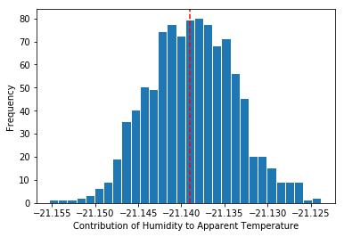

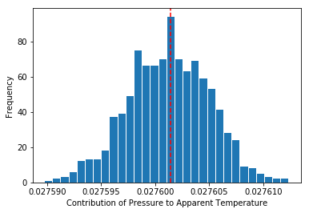

```python
# def plot(N_samples=400):

N_samples = 1000
# Now, lets sample parameters from posterior distribution
W = multivariate_normal(mean=mN.ravel(), cov=SN, size=[N_samples])
# W_density = np.zeros([N_samples,2])
# W_density[:,0] = norm.pdf(x=W[:,0], loc=mN[0,0], scale=SN[0,0])
# W_density[:,1] = norm.pdf(x=W[:,1], loc=mN[1,0], scale=SN[1,1])

# Humidities constribution
plt.figure()
plt.xlabel("Contribution of Humidity to Apparent Temperature")
plt.ylabel("Frequency")
plt.hist(W[:,0],bins=30,rwidth=0.9)
# plt.bar(x=W[:,0],height=sample)
plt.axvline(x=mN[0,0],color="red",linestyle="--")

# Pressure contribution
plt.figure()
plt.xlabel("Contribution of Pressure to Apparent Temperature")
plt.ylabel("Frequency")
plt.hist(W[:,1],bins=30,rwidth=0.9)
# plt.bar(x=W[:,0],height=sample)
plt.axvline(x=mN[1,0],color="red",linestyle="--")
plt.show()
```

```python
# interact(plot, x=widgets.IntSlider(min=300,max=1000));
```

We are now equipped with necessary information to proceed with predicting $y$. We defined posterior distribution over test target, given test input

\begin{align} \mathop{\mathbb{E}_{\theta,\varepsilon}}[y_{*}|X,y,x_{*}] & = \mathop{\mathbb{E}_{\theta}}[X^{T}\theta|X,y] \\ & = x_{*}^{T}\mathop{\mathbb{E}_{\theta}}[\theta|X,y] + 0 \\ & = x_{*}^{T}m_{N} \end{align}

\begin{align} \mathrm{Var}_{\theta,\varepsilon}[y_{*}|X,y,x_{*}] & = \mathrm{Var}_{\theta,\varepsilon}[x_{*}^{T}\theta+\varepsilon|X,y] \\ & = x_{*}^{T}\mathrm{Var}_{\theta}[\theta|X,y]x_{*} + \sigma^{2} \\ & = x_{*}^{T}S_{N}x_{*} + \sigma^{2} \end{align}

\begin{align} p(y_{*}|X,y,x_{*}) & = \int p(y_{*}|x_{*},\theta) p(\theta|X,y) d\theta \\ & = \int \mathcal{N}(y_{*}|X^{T}\theta,\sigma^{2}) \mathcal{N}(\theta|m_{N},S_{N}) d\theta \\ & = \mathcal{N}(y_{*}|x_{*}^{T}m_{N},x_{*}^{T}S_{N}x_{*} + \sigma^{2}) \end{align}

```
17.321021716380592
```

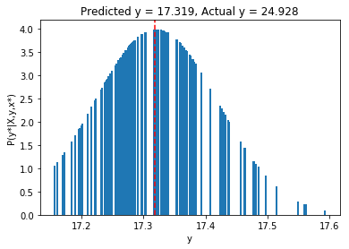

```python
test_index = np.random.randint(0,N)
test_x = X[test_index]
test_y = y[test_index]

test_mean = test_x.T @ mN
test_var = (test_x.T @ SN @ test_x) + var
y_samples = normal(loc=test_mean, scale=test_var, size=[100])
print(np.mean(y_samples))
y_density = norm.pdf(x=y_samples, loc=test_mean, scale=test_var)
plt.figure()
plt.title("Predicted y = %.3f, Actual y = %.3f"%(test_mean,test_y))
plt.xlabel("y")
plt.ylabel("P(y*|X,y,x*)")
plt.bar(y_samples, height=y_density, align='edge', width=0.003)
plt.axvline(x=test_mean, color="red", linestyle="--")
plt.show()
```

[output not shown]